# Phyloseq Demo

# Libraries

```r
#Load libraries
library(phyloseq)
packageVersion("phyloseq")
```

```
## [1] '1.10.0'
```

```r
library(Biostrings)
library(ggplot2)
library(vegan)
library(plyr)
library(scales)
library(grid)
library(reshape2)
library(gridExtra)
library(RColorBrewer)


# Set working directory
setwd("~/habs/genomics/data/")
```

# Data import

```r
# Import mothur files and sample metadata
sharedfile = "mothur/allhabs.shared"
taxfile = "mothur/allhabs.taxonomy"
mapfile = "best_metadata.csv"

mothurdata = import_mothur(mothur_shared_file = sharedfile,
                             mothur_constaxonomy_file = taxfile)

# Add the OTU number as a column in the taxonomy file
tax_table(mothurdata) <- cbind(tax_table(mothurdata),
                               row.names(tax_table(mothurdata)))

# Rename the taxonomy columns
colnames(tax_table(mothurdata)) <- c("Kingdom","Phylum","Class",
                                       "Order","Family","Genus","Species")

# Import sample metadata
map <- read.csv(mapfile)
map <- sample_data(map)
rownames(map) <- map$SampleID

# Merge mothurdata object with sample metadata
moth_merge = merge_phyloseq(mothurdata,map)

# Filter out non-samples (i.e. water,mock) and samples from intensive cruises.
# Also prune out taxa which were only present in removed samples
moth_good <- subset_samples(moth_merge,Type=="sample")
moth_good <- prune_taxa(taxa_sums(moth_good)>0,moth_good)

# Filter out non-bacteria, chloroplasts and mitochondria
moth_good <- subset_taxa(moth_good, Kingdom == "Bacteria")
moth_good <- subset_taxa(moth_good, Class != "Chloroplast")
moth_good <- subset_taxa(moth_good, Family!="mitochondria")
```

# Sample summary

A lot of the 100um samples have very low read counts because a majority of the reads were chloroplasts. Before removing non-bacteria, all samples had at least 10,000 reads, afterwards many of the 100L samples had as few as 500 reads. This is important to keep in mind for beta diversity analyses, because to include all the samples we need to really throw out a lot of data to normalize the sequencing depth.

```
## stat_bin: binwidth defaulted to range/30. Use 'binwidth = x' to adjust this.
```

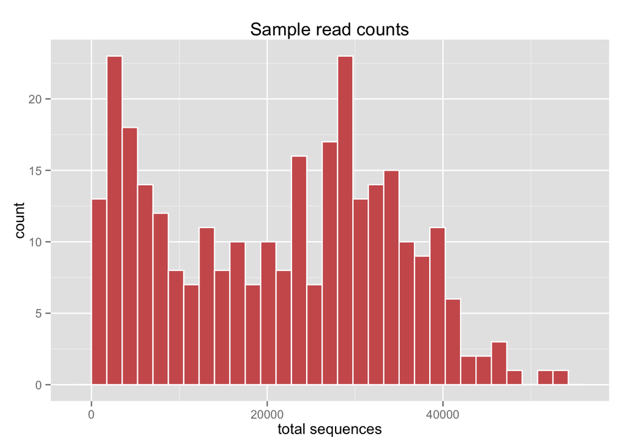